# Old Wounds Still Run Deep: An Observation of Segregation and Inequality in Richmond

Andrew Geha

## Overview

Given the heavily racialized history of Richmond, VA, I thought it would be interesting to observe racial and economic relationships in the city using data from the census tracts. After filtering out Richmond’s data from the country’s census tracts, I observed variables of race, average household income based on certain quintiles, and specific age percentages of the city’s residents. The data consisted of statistics from counties including Richmond City and Henrico, as well as from surrounding counties like Chesterfield County, King William County, and Sussex County. Based on the information provided, it is clear that Richmond’s neighborhoods are still sharply segregated along racial lines. Furthermore, there are clear income disparities based on race.

## Mapped Racial Demographics

Certain housing policies implemented during and after the time of the Jim Crow laws ensured that even after the Emancipation Proclamation, neighborhoods in Richmond would be segregated along racial lines (Ramsey, 2015). Because of the crippling effects of the institution of slavery on Black Americans, they lacked quality levels of education as well as sufficient economic skills to succeed at the necessary levels of an increasingly-industrial nation. Therefore, the neighborhoods that Black people were segregated into did not possess many opportunities across good education and jobs, contrasted with White neighborhoods in which people had quality educational and economic opportunities.

Although conditions have improved for Black Americans–the richest 20 percent of them saw their net worth raise by 63 percent between 2000 and 2011–it is still interesting to see if neighborhoods have remained segregated (Samuelson, 2014). According to the map of Richmond below, the city and surrounding area remain heavily segregated.

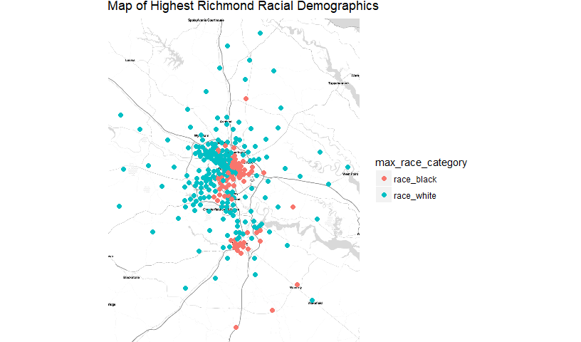

As the map shows, high concentrations of Richmond residents on the west side of the city are predominantly white (represented by teal dots). On the eastern side of the city, we can see that Black citizens (red dots) are clustered in neighborhoods together. In the southern side of the area, in which there is a noticable concentration of Black residents, some slight groupings of teal dots (representing White residents) can be seen near the relatively big cluster of red dots. However, there is no clear mixture of teal and red dots; neighborhoods appear to be predominantly segregated.

The distinctions between the racial lines of the city are striking, particularly in what is known as the city’s West End. This area in Richmond is known to be the wealthier side to the city, and the fact that the West End is clearly dominantly white begs questions of the distribution of wealth in the city, which seems at face value to be remarkably unequal.

## Race and Average Household Income

Unfortunately, statistics have demonstrated that the wealth inequality gap between white and black people in Richmond is stark. According to Adesanya (2013), who compared Windsor Farms in Richmond’s West End to Gilpin in Richmond’s Northside, the average household income in the former neighborhood was $185,000, compared to an average of less than $10,000 in Gilpin. According to the scatterplot below, it appears that stark contrasts in household incomes may be more widespread than just that one case.

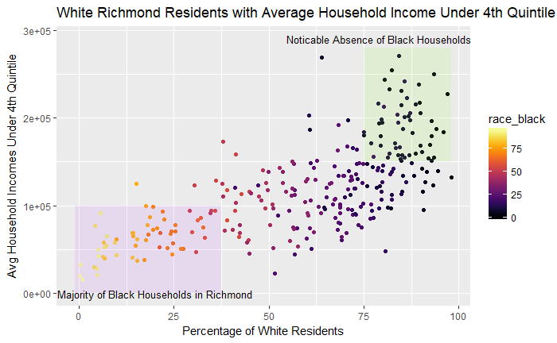

## Age, Race, and Average Household Income

Still focusing on households with average incomes through the first 3 economic quintiles, the next visualization portrays Richmond residents between the ages of 18 and 59, regardless of race. According to the Organisation for Economic Co-operation and Development, the working age population consists of those between the ages of 15 and 64 (“Working Age Population,” 2018); so the 18-59 range is relatively close to depicting the average age range of the actual working population. Filtered into the graph is spectrum that depicts how White Richmond residents fit into the larger working population sample of the plot. This filter was created to compare where average White working citizen’s income in Richmond compares to the rest of the average working population.

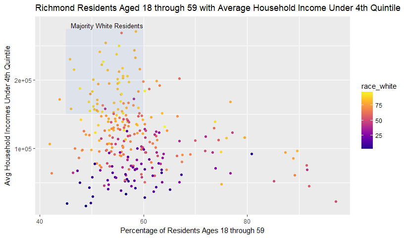

Although this graph does not specify where racial minorities in Richmond are positioned on this graph, the large concentration of white residents toward trending upward along the y-axis is very telling about where much of the wealth is distributed in Richmond–toward the White residents.

## Conclusion

The visualizations above confirm that Richmond is still very segregated along both neighborhood lines and, drastically, economic lines. Added to living in predominantly white neighborhoods, White Richmond residents are making significantly more on average than Black residents, and the differences in economic outcomes are quite stark.

## References

Adesanya, I. (2013, December 20). Richmond Ranks High in Income Inequality. Retrieved from http://mmj.vcu.edu/2013/12/20/how-income-inequality-divides-richmond/

Demography - Working age population - OECD Data. (n.d.). Retrieved March 07, 2018, from https://data.oecd.org/pop/working-age-population.htm

Perriello, T. (2017, February 23). Tackling the Racial Wealth Gap. Retrieved from https://medium.com/tom-for-virginia/tackling-the-racial-wealth-gap-959ff8e0131c

Ramsey, J. (2015, April 23). Public Square Explores Segregation in Richmond. Richmond Times-Dispatch. Retrieved from http://www.richmond.com/public-square/public-square-explores-segregation-in-richmond/article_828d2adb-2178-59b7-ac76-875d37460226.html

Samuelson, R. (2014, August 28). Samuelson: Wealth Inequality: Some Hidden Good News. Richmond Times-Dispatch. Retrieved from http://www.richmond.com/opinion/their-opinion/robert-samuelson/samuelson-wealth-inequality-some-hidden-good-news/article_765611c9-5466-5e66-af44-590772974cb1.html